# Intro to Git

Brad Rentz

3/21/2017

# What is Git?

# Git is…

- A distributed version control system
- Used to allow multiple people to collaborate on the same code
- Also useful for managing your own code and larger projects

# Applications for language researchers?

- Coauthoring papers
- Working on R scripts or other code
- Sharing code with others (via github or bitbucket)
- Managing large projects like a dissertation, thesis, or article

# What does Git do?

- Git repositories store the history of files contained in it
- Changes to files are tracked and can also be undone
- Also allows for multiple **branches** which store multiple versions of the same file (production versions vs development versions vs experimental approaches or various draft verions)
- Git stores this information **locally** but can also save it **remotely** on github or other platforms
- Mainly accessed through terminal or command line

# How do we use Git?

# The Basic Local Git Workflow

1. Create Git repository
2. Add files so that Git tracks them (staging files)
3. After done editing commit changes (committing files)

# Git config

Basic Git configuration if haven’t done so already

```bash
# configure the user which will be used by Git
# this should be not an acronym but your full name
git config --global user.name "Firstname Lastname"

# configure the email address
git config --global user.email "your.email@example.org"
```

# Creating a Git Repository

- Create a folder for the project (or use an existing one)
- Navigate via terminal/command line to that folder
- Then run `git init`

```bash
cd ~/Desktop/sample_git
git init
```

```
## Reinitialized existing Git repository in /Users/brad_rentz/Desktop/sample_git/.git/
```

# Check Git Status

- Now that the repository is created we can check the status of the repository
- You can run this at any point too

```bash
cd ~/Desktop/sample_git
git status
```

```
## On branch experimental
## Untracked files:
##   (use "git add <file>..." to include in what will be committed)
##
##  .DS_Store
##  sample/
##  sample2.R
##
## nothing added to commit but untracked files present (use "git add" to track)
```

# Staging files

- We have to tell Git which files to track
- We add them with `git add FILENAME`
- Add `sample.R`

```bash
cd ~/Desktop/sample_git
git add sample.R
# too add all R files in directory
# use 'git add *.R'
git status
```

```
## On branch experimental
## Untracked files:
##   (use "git add <file>..." to include in what will be committed)
##
##  .DS_Store
##  sample/
##  sample2.R
##
## nothing added to commit but untracked files present (use "git add" to track)
```

# Commit files

- Staging files only tell Git to look for change but not to remember them
- Commit tell Git to remember how the files are at that moment (it commits all staged files)
- Use `git commit -m "Commit message"`
- `-m` adds a message argument

```bash
cd ~/Desktop/sample_git
git commit -m "First commit"
# the message added should explain the changes
git status
```

```
## On branch experimental
## Untracked files:
##  .DS_Store
##  sample/
##  sample2.R
##
## nothing added to commit but untracked files present
## On branch experimental
## Untracked files:
##   (use "git add <file>..." to include in what will be committed)
##
##  .DS_Store
##  sample/
##  sample2.R
##
## nothing added to commit but untracked files present (use "git add" to track)
```

# Modifying a file

- Let’s change the file to see what happens
- Make some changes to `sample.R` then check the `git status`

```bash
cd ~/Desktop/sample_git
# changed the sample.R file
git status
```

- What does the `git status` say?

# Commit changes

- After you modify a file, you can commit it again by first doing `git add filename` then `git commit -m "message"` **or**
- You can use `git commit -a -m "message"`
- `-a` tells git to commit all changes to previously staged files

```bash
cd ~/Desktop/sample_git
git commit -a -m "made some changes"
```

# Summary (so far)

```bash
cd ~/Desktop/sample_git # go to the right folder
git init # create repository (only run first time)
git add *.R # add all .R files (staging)
git commit -a -m "made some changes" # commit the files
```

# Branching

# What is branching?

- Branches are different versions of the same code
- Git allows us to create branches instead of creating a completely new folder for changes
- Git manages the changes between version for us and even changes what files appear depending on which branch we are in
- Git can even merge branches back together if needed

# Why is branching helpful?

- Branching allows us to have multiple versions of the code each with separate histories so we can undo certain features on
- This is useful if we want to experiment with our code with a new analysis while being able to keep code that we know works
- Can even use this with non-code like text documents
- Can have multiple versions of papers or dissertations (especially if using LaTeX or R markdown)
  - Modify an article for different purposes
  - Manage comments from committee members or reviewers

# Creating new branch

- To create a new branch use `git branch NAME`
- Using `git branch` will give you a list of all branches

```bash
cd ~/Desktop/sample_git
git branch experimental
git branch
```

```
## fatal: A branch named 'experimental' already exists.
## * experimental
##   master
```

# Switching between branches

- To switch between branches use `git checkout NAME`
- Notice after switching branches the file name change (even in Finder for macOS)
- Note: I added a `sample3.R` to experimental

```bash
cd ~/Desktop/sample_git
git checkout master
# see file list before switching branches
ls
git checkout experimental
# see file list afterward
ls
```

```
## Switched to branch 'master'
## sample
## sample.R
## sample2.R
## Switched to branch 'experimental'
## sample
## sample.R
## sample2.R
## sample3.R
```

# Merging branches

- Sometimes it is helpful to merge branches together
- First checkout into the branch you want to keep (master)
- Then use `git merge NAME` where name is the branch you want to merge into that branch
- If there are problematic merges, Git won’t complete the merge. If so use `git mergetool` then `git commit -a -m "message"`

```bash
cd ~/Desktop/sample_git
git checkout master # switch to branch want to keep
git merge experimental # merge experimental into master
git mergetool # only if it won't merge
git commit -a -m "merged experiemental into master" # only if used diff tool
```

# Deleting Merged Branches

- After a branch is successfully merged into another branch, you can delete it with `git branch -d NAME`
- `-d` will only delete the branch if it has been merged (this is a safe delete)
- If you created a branch and you don’t like it and want to delete it without merging use `git branch -D NAME`

```bash
cd ~/Desktop/sample_git
git branch -d experimental
git branch crazy-idea # create this branch
git branch -D crazy-idea # nevermind, too crazy, delete it
```

# Using Git with Github

# Creating github repository

- If you are using your own code, the first step is to make a local git repository, which we did already
- Then on github make a new repository but an empty one
- After creating it look for directions like these and run them in terminal (you need to `cd` to your local git repository first. You may need to enter your github username and password):

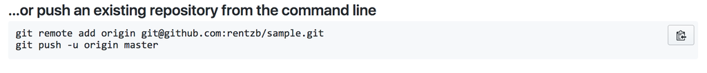

# Pushing to Github

- After you link your local repository to github, you can send your changes directly by using `git push`
- This will only work if there are no other changes by others

```bash
cd ~/Desktop/sample_git
git push # send code to linked github repository
# or if you want to specify branches
git push origin experimental # pushes experimental branch
```

# Pulling files

- To get the current version of files on github if they differ from local repository use `git pull`
- Git won’t let you `push` something if there are conflicts, so good to `pull` first, then deal with conflicts, then `push`.
- If conflicts arise use `git diff` to see differences and `git mergetool` to merge

```bash
cd ~/Desktop/sample_git
git pull # get code from linked github repository
git diff # use if conflicts
```

# Summary

```bash
cd ~/Desktop/sample_git # go to the right folder
git init # create repository (only run first time)
git branch experimental # creates new branch called experimental
git checkout experimental # switches branches
git add *.R # add all .R files (staging)
git commit -a -m "made some changes" # commit the files
git pull # get current remove version
git mergetool # use if need to resolve conflicts
git push # saves to remote repo
```

# Other Git Things

# Git Misc

- `git log` gives you the history of changes
- `git clone URL name` clones an online git repo to your computer with name `name` and sets up a git repo for it
- `git grep "STRING"` searches through commits for that string
- `.gitignore` is file that includes filetypes to ignore (you can find good ones online for each language) [save them in the top folder for each git repo]

# Other Git Resources

# Git Tutorials

- https://git-scm.com/docs/gittutorial
- http://www.vogella.com/tutorials/Git/article.html
- https://blog.udemy.com/git-tutorial-a-comprehensive-guide/
- http://gitimmersion.com/lab_01.html
- http://rogerdudler.github.io/git-guide/

# More Git Resources

- Free book on Git https://git-scm.com/book/en/v2
- Youtube video series https://www.youtube.com/GitHubGuides
- Git command reference guide http://gitref.org/
- Git cheatsheet https://services.github.com/on-demand/downloads/github-git-cheat-sheet.pdf